# HW#2e3_main

## Exercise 3. Principal Component Analysis

### (i) Perform a PCA on the winter global SST anomalies

Source libraries, data and functions. Import and setup SST data

```r
setwd("C:/Users/alexb/Google Drive/CVEN 6833 ADAT/zz Homeworks/HW#2/CVEN6833-HW-2")
set.seed(1) # Set seed to repodruce results
# Libraries, functions (and variables) are sourced from the last chunk ("sources") at the end of the page.

require(magrittr)

nrows=72 # data import setup
ncols=36
nyrs = 118  # Nov-Mar avg 1901 - 2018

xgrid=seq(27.5,382.5,by=5) #Generate grid (-180,180) format
xgrid[xgrid>180]=xgrid[xgrid>180]-360
ygrid=seq(-87.5,87.5,by=5)
xygrid=expand.grid(x=xgrid,y=ygrid) %>% .[c("y","x")] # Lat - Long grid..

kaplan = # SST data row per NDJFM season format
  readBin("http://civil.colorado.edu/%7Ebalajir/CVEN6833/HWs/HW-2-2018/Kaplan-SST-NDJFM1900-NDJFM2018.r4",what="numeric", n=( nrows * ncols * nyrs), size=4,endian="swap") %>% # Read Kaplan SST data..
  array(data = ., dim=c( nrows*ncols, nyrs ) ) %>% t(.) # 2D

index1=kaplan[1,]<10 & kaplan[1,] != "NaN"
sstdata=kaplan[,index1] # Drop missing data
```

The PCA is performed using the SST data. First we calculate the variance matrix, SVD decomposition, and Eigenvalues.

```r
zsvd = sstdata %>% scale(.) %>% var(.) %>% svd(.) # scale # get variance # Eigen decomposition
pcs=t(t(zsvd$u) %*% t(scale(sstdata))) #Principal Components...
lambdas=(zsvd$d/sum(zsvd$d)) #Eigen Values.. - fraction variance explained
```

#### Plot of variance explained by each principal component

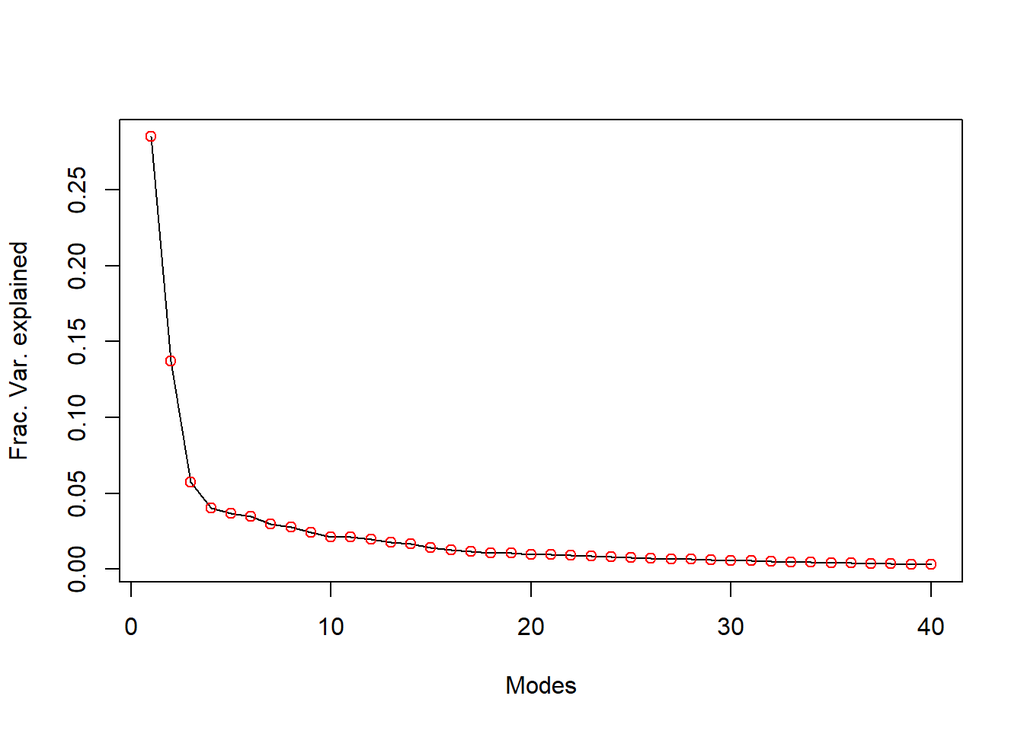

```r
plot(1:40, lambdas[1:40], type="l", xlab="Modes", ylab="Frac. Var. explained")
points(1:40, lambdas[1:40], col="red")
```

#### First four spatial components or Eigen Vector patterns

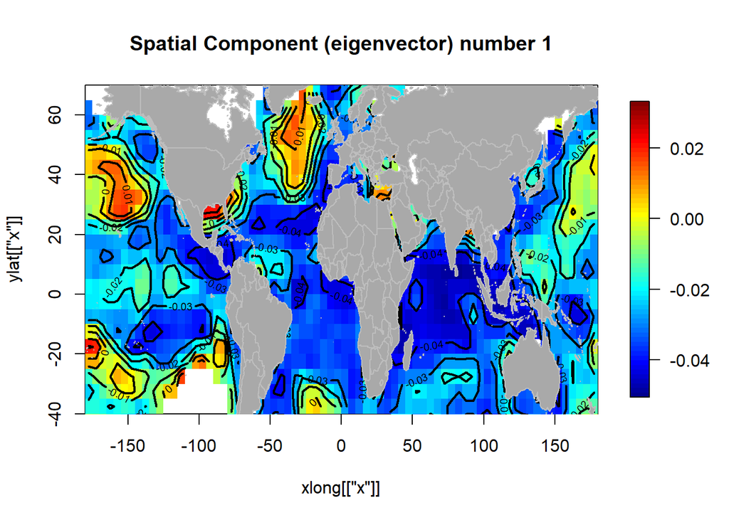

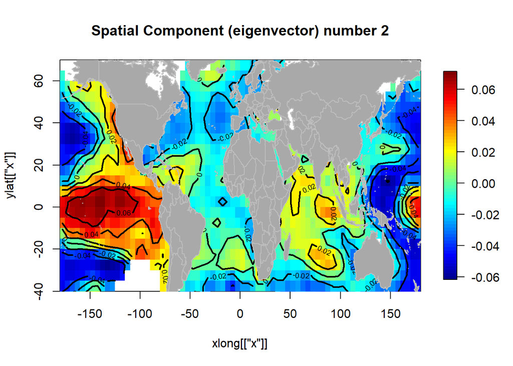

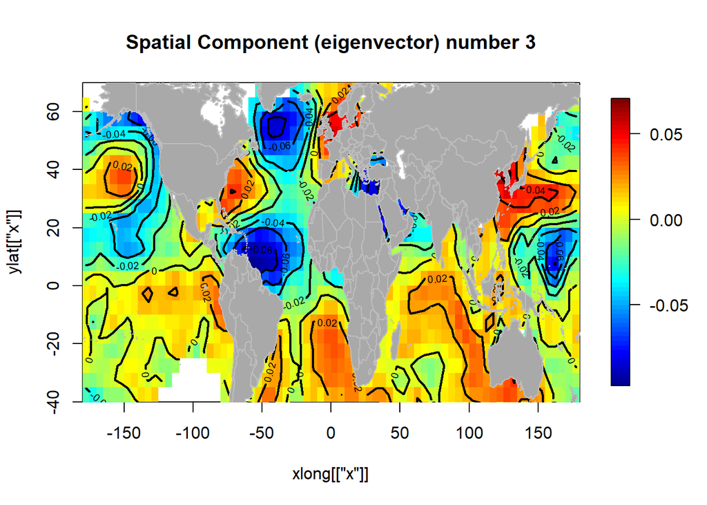

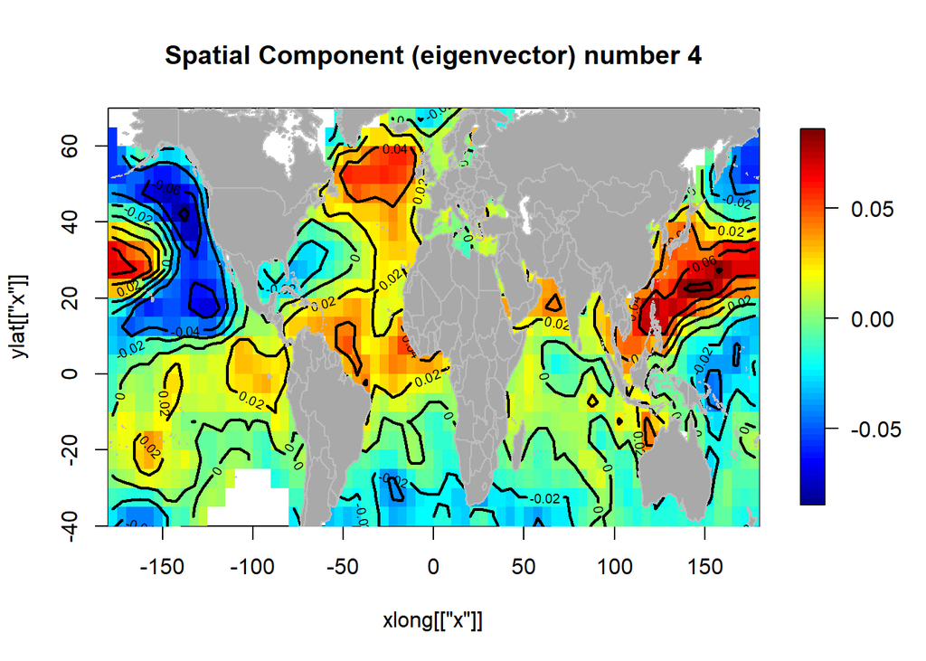

```r
xlong = sort(xgrid,index.return=TRUE)
ylat = sort(ygrid,index.return=TRUE)

for(i in 1:4){
  zfull = rep(NA,length(xygrid[,1]))
  zfull[index1]=zsvd$u[,i]
  zmat = matrix(zfull,nrow=nrows,ncol=ncols)
  zmat = zmat[xlong[["ix"]],] %>% .[,ylat[["ix"]]] # match SST values with sorted rows,columns

  image.plot(xlong[["x"]],ylat[["x"]],zmat,ylim=range(-40,70),main=paste("Spatial Component (eigenvector) number",i))
  contour(xlong[["x"]],ylat[["x"]],zmat,ylim=range(-40,70),add=TRUE,nlev=6,lwd=2)
  world(fill=TRUE, col="darkgray",border="gray",add=TRUE)
}
```

#### First four Principal Components (time)

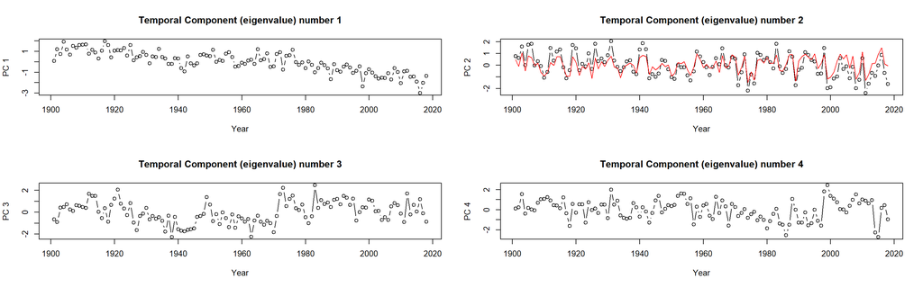

```r
par(mfrow=c(2,2))
nino4=scan("http://iridl.ldeo.columbia.edu/SOURCES/.Indices/.nino/.EXTENDED/.NINO4/T/(Nov%201899)/(Mar%202018)/RANGE/T/(Nov-Mar)/seasonalAverage/data.ch") # ENSO data

for(i in 1:4){
  plot(seq(from=1901,length.out=nyrs), scale(pcs[,i]),type="b",xlab="Year",ylab=paste("PC",i),main=paste("Temporal Component (eigenvalue) number",i))
  if(i==2){lines(1901:2018, nino4, col="red")
    legend(x=1,y=1,legend=c("PC","ENSO"))}
}
```

### (ii) Rotate the first 6 PCs and plot the leading 4 spatial and temporal modes of variability There are three ways to do it, see: https://stats.stackexchange.com/questions/59213/how-to-compute-varimax-rotated-principal-components-in-r We will use the varimax function and calculate the scores via rotation matrix

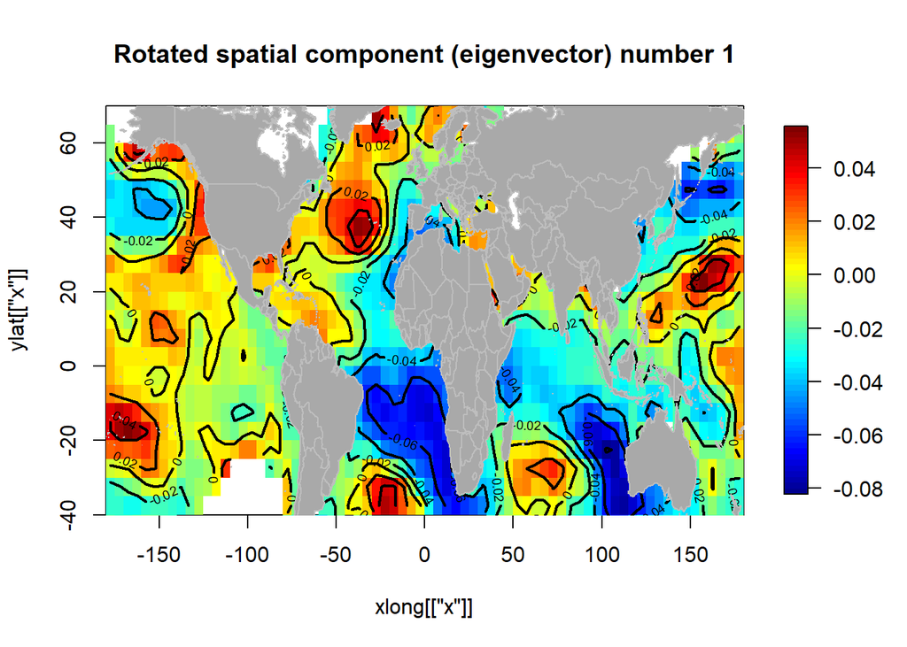

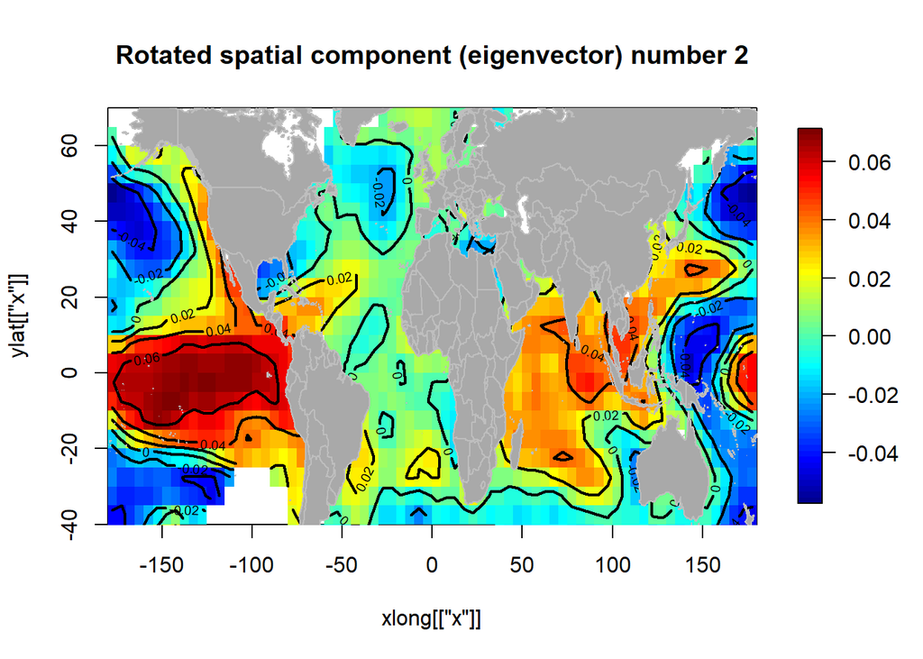

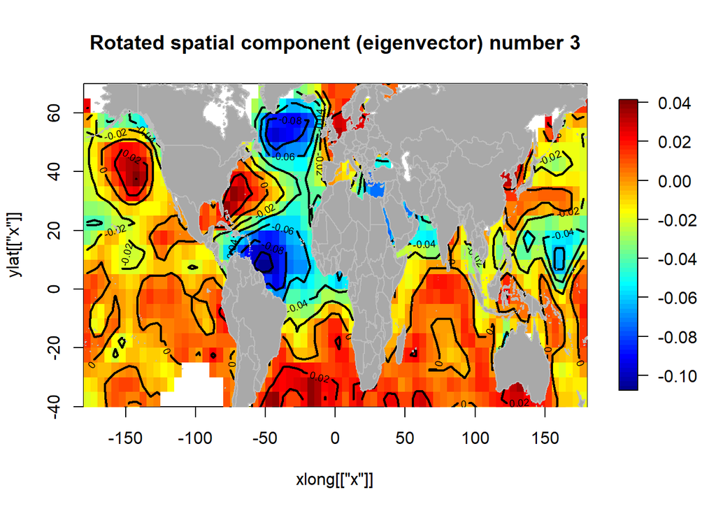

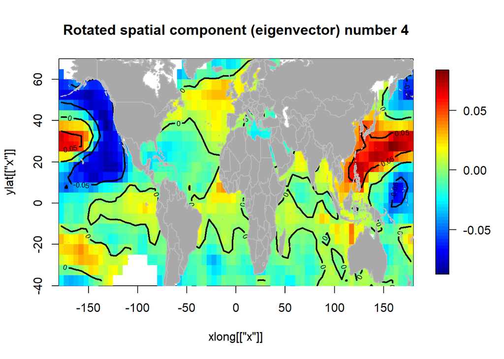

```r
zrot = varimax(zsvd$u[,1:6],normalize=FALSE)
for(i in 1:4){
  zfull = rep(NA,length(xygrid[,1]))
  zfull[index1]=zrot$loadings[,i]
  zmat = matrix(zfull,nrow=nrows,ncol=ncols)
  zmat = zmat[xlong[["ix"]],] %>% .[,ylat[["ix"]]] # match SST values with sorted rows,columns

  image.plot(xlong[["x"]],ylat[["x"]],zmat,ylim=range(-40,70),main=paste("Rotated spatial component (eigenvector) number",i))
  contour(xlong[["x"]],ylat[["x"]],zmat,ylim=range(-40,70),add=TRUE,nlev=6,lwd=2)
  world(fill=TRUE, col="darkgray",border="gray",add=TRUE)
  }
```

The use of rotated PCA allows us to observe a more acute spatial distribution of the eigenvectors

The rotated temporal components are:

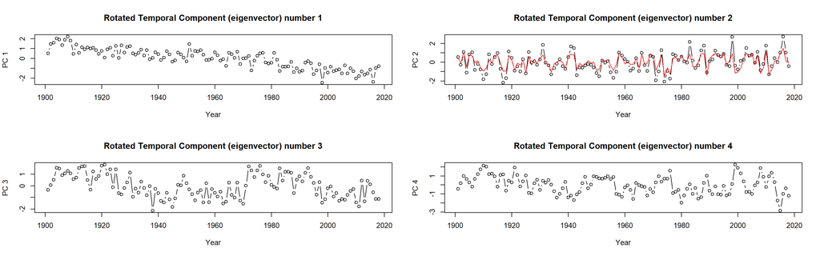

```r
par(mfrow=c(2,2))
rotpcs=t(t(zrot$loadings) %*% t(scale(sstdata)))
for(i in 1:4){
  plot(seq(from=1901,length.out=nyrs), scale(rotpcs[,i]),type="b",xlab="Year",ylab=paste("PC",i),main=paste("Rotated Temporal Component (eigenvector) number",i))
    if(i==2){lines(1901:2018, nino4, col="red")
    legend(x=1,y=1,legend=c("PC","ENSO"))}
}
```

This temporal components seem similar to the originals.

### (iii) Perform PCA and rotated PCA on the western US winter precipitation (Nov1900 – Mar2013) 113

yrs First we import grid location and precipitation data

```r
N = 113 # Time window
wuplocs = matrix(scan("http://civil.colorado.edu/%7Ebalajir/CVEN6833/HWs/HW-2-2018/WesternUS-coords.txt"), ncol=5,byrow=T)
nlocs = dim(wuplocs)[1]
xlats = wuplocs[,3]
xlongs = -wuplocs[,4]

winterprecip = matrix(scan("http://civil.colorado.edu/%7Ebalajir/CVEN6833/HWs/HW-2-2018/western-US-winterprecip-1901-2014.txt"),ncol=nlocs+1,byrow=T)
years = 1901:2013
winterprecip = winterprecip[,2:(nlocs+1)]       #first column is year
```

#### Do PCA on precipitation data

```r
zsvd = winterprecip %>% scale(.) %>% var(.) %>% svd(.) # Eigen decomposition
pcs=t(t(zsvd$u) %*% t(scale(winterprecip))) # Principal Components
lambdas=(zsvd$d/sum(zsvd$d)) # Eigenvalues
```

#### Variance explained by each principal component

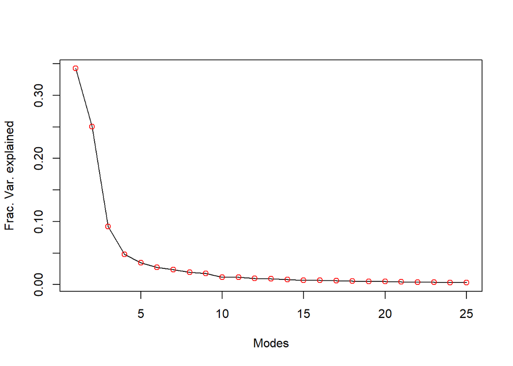

```r
plot(1:25, lambdas[1:25], type="l", xlab="Modes", ylab="Frac. Var. explained")
points(1:25, lambdas[1:25], col="red")
```

#### First four spatial components or Eigen Vector patterns

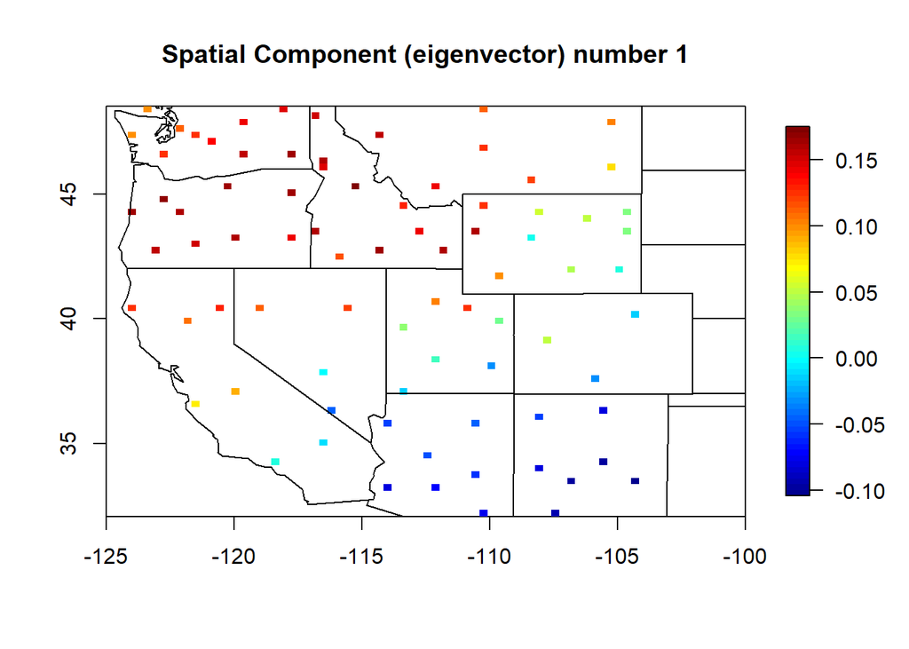

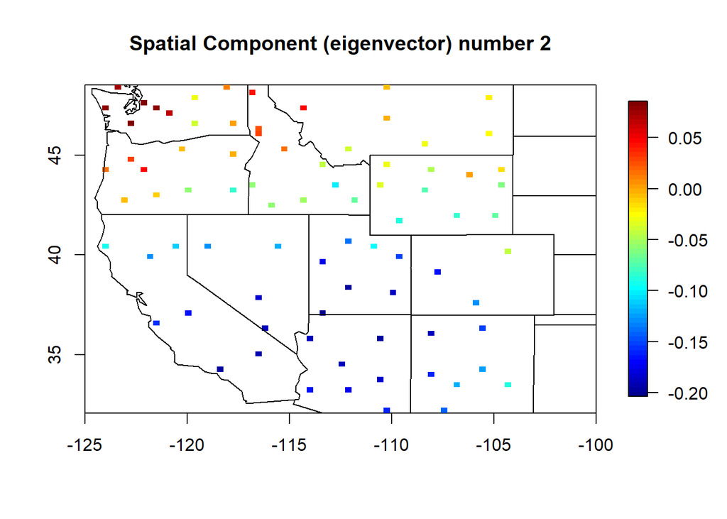

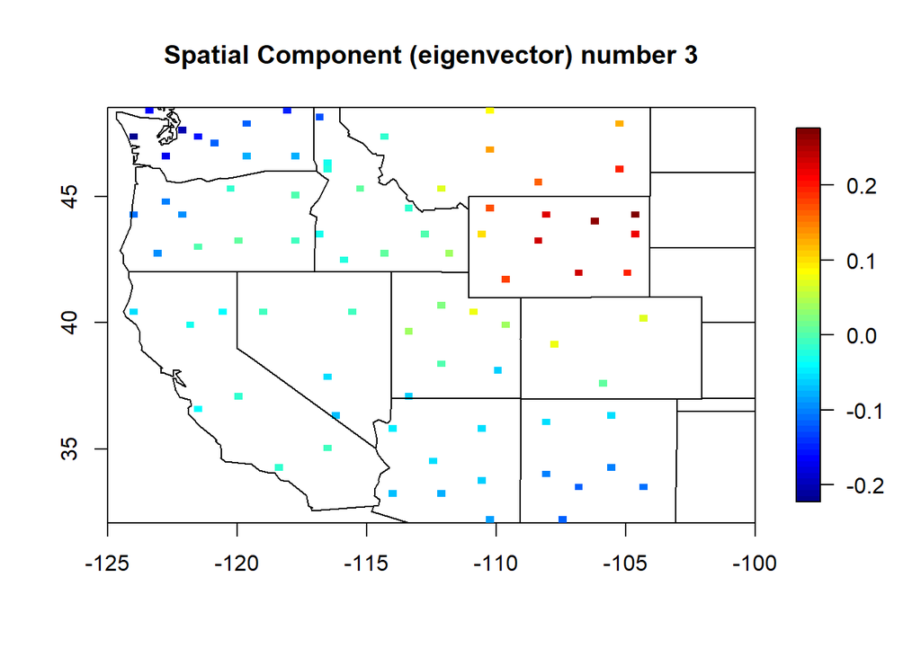

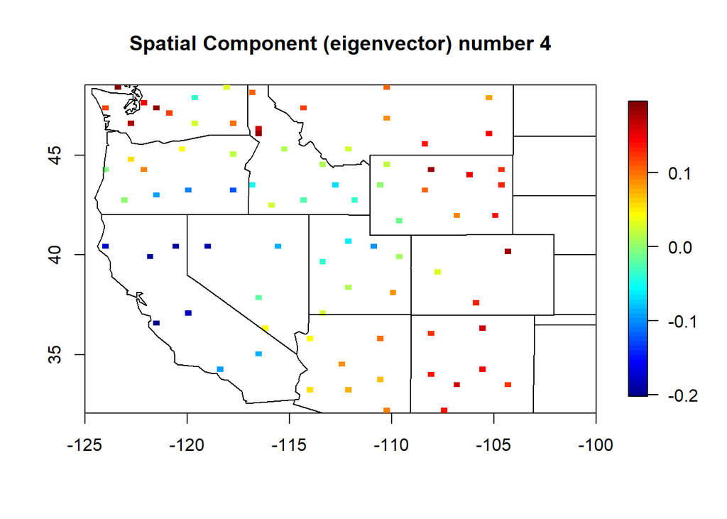

```r
for(i in 1:4){
  quilt.plot(xlongs,xlats,zsvd$u[,i],xlim=range(-125,-100),main=paste("Spatial Component (eigenvector) number",i))
  maps::map("state",add=TRUE)
}
```

#### First four Principal Components (time)

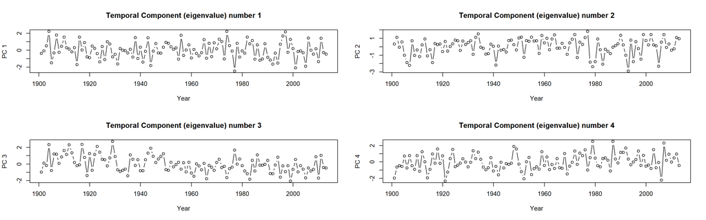

```r
par(mfrow=c(2,2))
westernpcs=as.data.frame(matrix(, nrow = length(pcs[,1]), ncol = 4))
colnames(westernpcs)=c("PC1","PC2","PC3","PC4")
for(i in 1:4){
  westernpcs[,i]=scale(pcs[,i])
  plot(seq(from=1901,length.out=N),scale(pcs[,i]),type="b",xlab="Year",ylab=paste("PC",i),main=paste("Temporal Component (eigenvalue) number",i))
}
```

#### Rotation of the first 6 first PCs and plot of the leading 4 spatial and temporal modes of variability

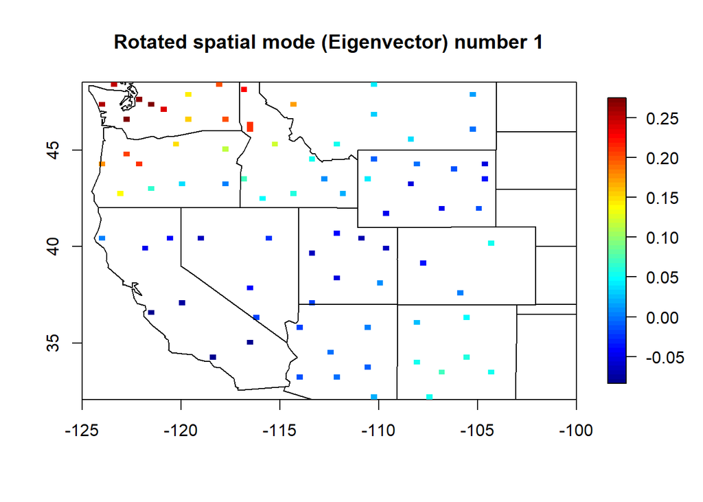

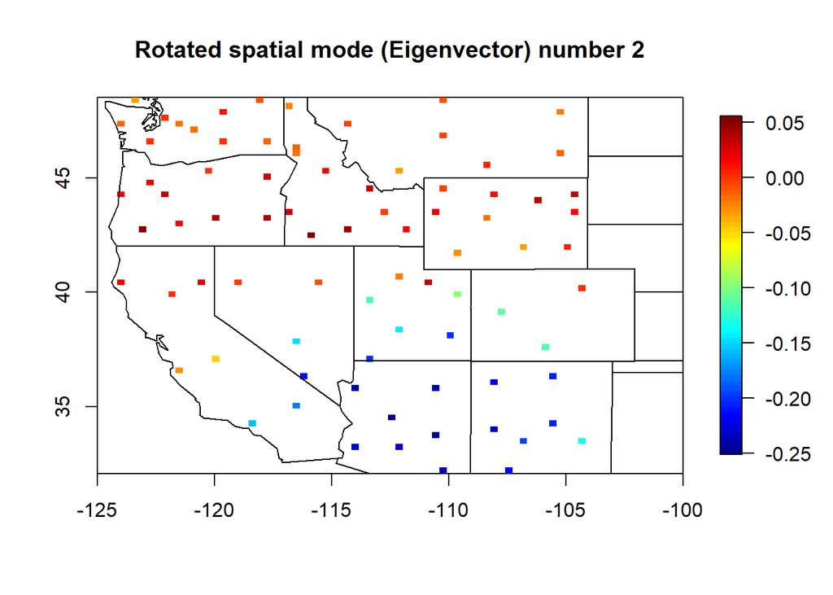

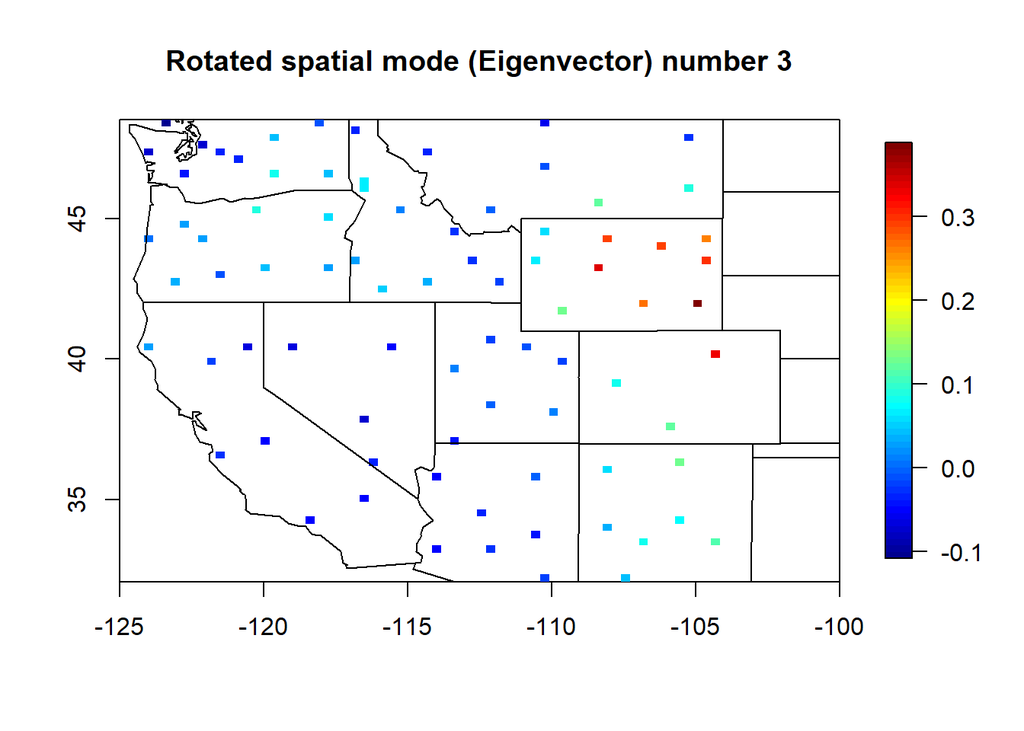

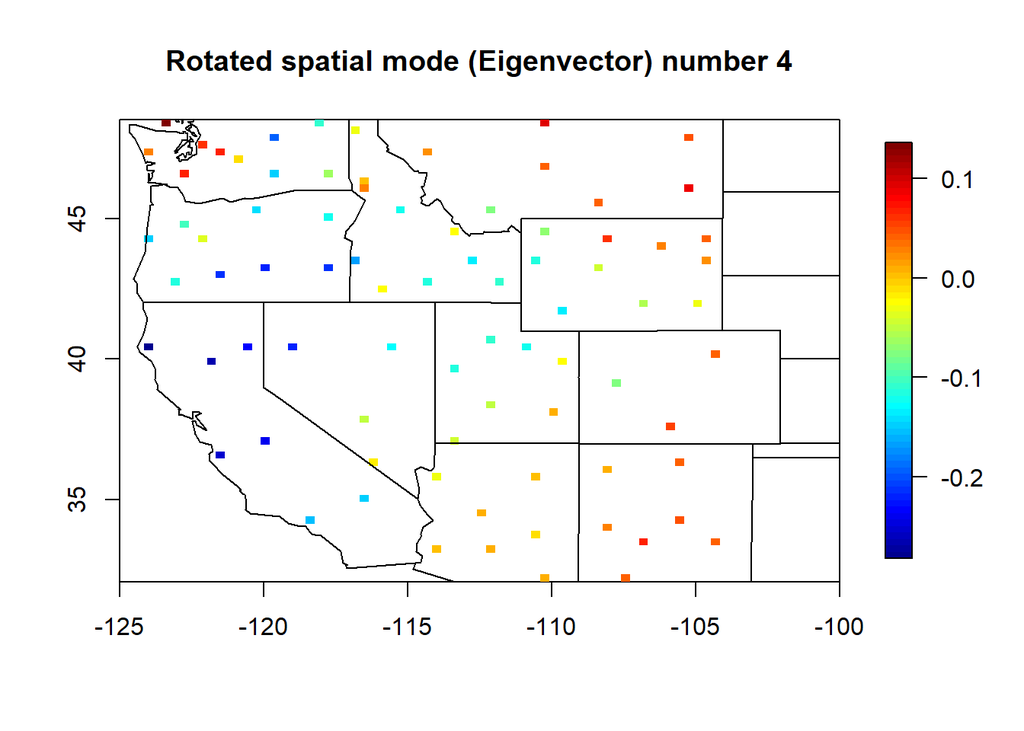

```r
zrot = varimax(zsvd$u[,1:6],normalize=FALSE)
for(i in 1:4){
  quilt.plot(xlongs, xlats, zrot$loadings[,i],xlim=range(-125,-100),main=paste("Rotated spatial mode (Eigenvector) number",i))
  map("state",add=TRUE)
}
```

#### Plot of the first four rotated PC

A simple glm is added to show trend.

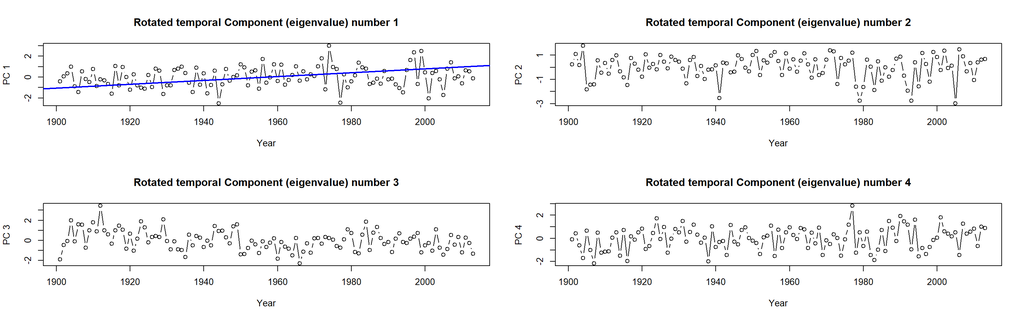

```r
par(mfrow=c(2,2))
rotpcs=t(t(zrot$loadings) %*% t(scale(winterprecip)))
for(i in 1:4){
  plot(seq(from=1901,length.out=N), scale(rotpcs[,i]),type="b",xlab="Year",ylab=paste("PC",i),main=paste("Rotated temporal Component (eigenvalue) number",i))
  if(i==1){
    abline(glm(rotpcs[,i]~seq(from = 1901,length.out = N)), col="blue", lwd=2) # trend
  }
  }
```

To perform PCA on the Pacific Ocean grid only, we retrieve kaplan and trim grid to study area

```r
pacgrid=xygrid$y >= -20 & (xygrid$x >= 105 | xygrid$x <= -70) #grid limits
indexpac=index1 & pacgrid # locations on kaplan grid
xygrid1 = xygrid[indexpac,] # coordinates on kaplan grid

sstannavg = kaplan[,indexpac] # Pacific data
```

Now we do PCA on data

```r
zsvd = sstannavg %>% scale(.) %>% var(.) %>% svd(.) # SVD decomposition
pcs=t(t(zsvd$u) %*% t(scale(sstannavg)))
lambdas=(zsvd$d/sum(zsvd$d))
```

#### Plot of variance explained by each principal component

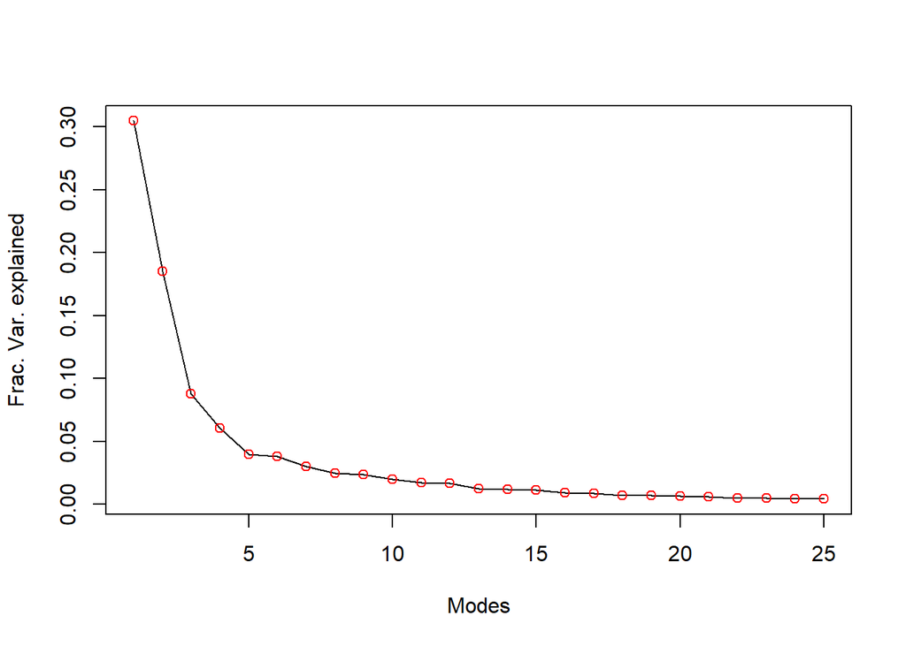

```r
plot(1:25, lambdas[1:25], type="l", xlab="Modes", ylab="Frac. Var. explained")
points(1:25, lambdas[1:25], col="red")
```

#### First four spatial components or Eigen Vector patterns

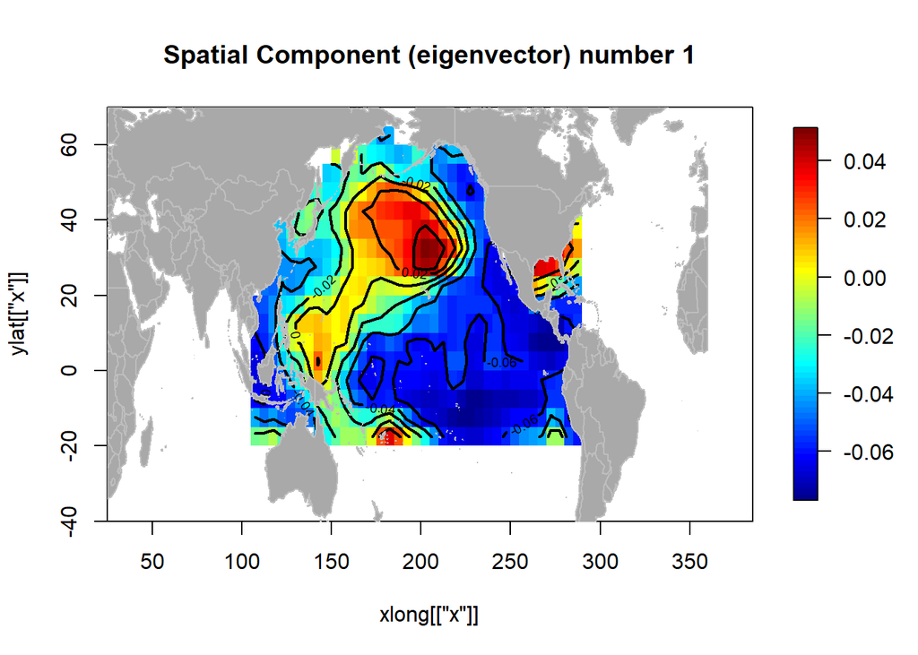

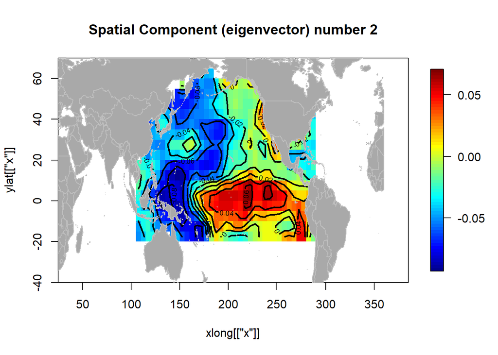

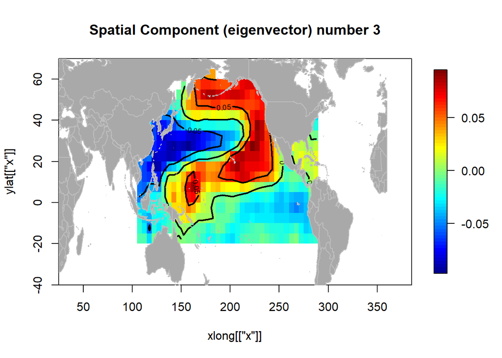

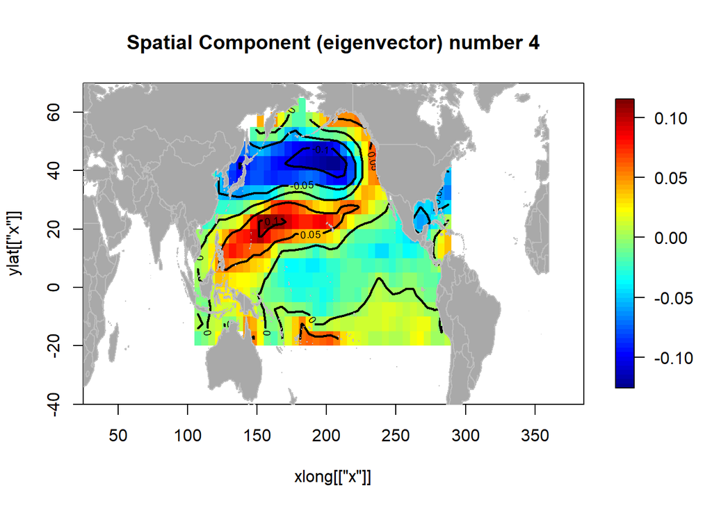

```r
xgrid=seq(27.5,382.5,by=5) #Generate grid (27.5,382.5) format
xlong = sort(xgrid,index.return=TRUE)
ylat = sort(ygrid,index.return=TRUE)

for(i in 1:4){
  zfull = rep(NA,length(xygrid[,1]))
  zfull[indexpac]=zsvd$u[,i]
  zmat = matrix(zfull,nrow=nrows,ncol=ncols)
  zmat = zmat[xlong[["ix"]],] %>% .[,ylat[["ix"]]] # match SST values with sorted rows,columns

  image.plot(xlong[["x"]],ylat[["x"]],zmat,ylim=range(-40,70),main=paste("Spatial Component (eigenvector) number",i))
  contour(xlong[["x"]],ylat[["x"]],zmat,ylim=range(-40,70),add=TRUE,nlev=6,lwd=2)
  maps::map("world2",fill = TRUE,col="darkgray",border="gray",add=TRUE)
}
```

#### First four Principal Components (time)

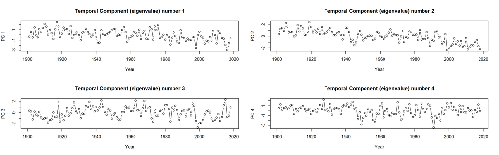

```r
par(mfrow=c(2,2))
pacificpcs=as.data.frame(matrix(, nrow = length(pcs[,1]), ncol = 4))
colnames(pacificpcs)=c("PC1","PC2","PC3","PC4")
for(i in 1:4){
  pacificpcs[,i]=scale(pcs[,i])
  plot(seq(from=1901,length.out=nyrs), scale(pcs[,i]),type="b",xlab="Year",ylab=paste("PC",i),main=paste("Temporal Component (eigenvalue) number",i))
}
```

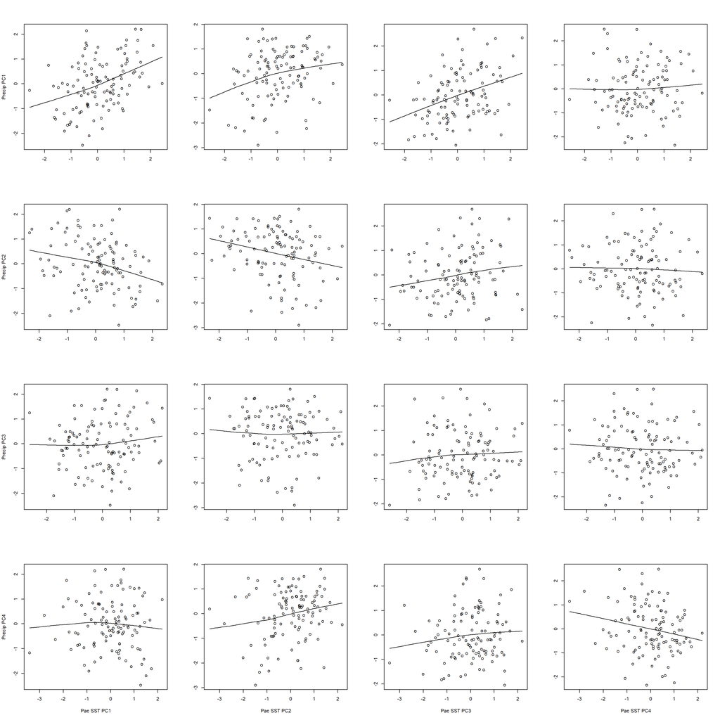

```r
par(mfrow=c(4,4))
par(pty="m")
for(i in 1:4){
  for(j in 1:4){
    fit=locfit(westernpcs[,j]~pacificpcs[1:113,i],alpha=1,deg=1)
      plot(fit,get.data=TRUE,ylab=ifelse(j==1,paste("Precip",colnames(westernpcs)[i]),""),xlab=ifelse(i==4,paste("Pac SST",  colnames(pacificpcs)[j]),""))
    # }
    }
  }
```

All relations show low correlation, indicating that the results may be wrong.Relation Pacific SST PC2 - PreciP PC1 has a significant parameter in a linear regression, but R2 is only 0.07.

#### Aux code to call libraries, own functions and variables

```r
##
## Source Libraries
##
libr=c("magrittr","maps","akima","fields","tidyr","locfit")
options(warn=-1)
suppressPackageStartupMessages(lapply(libr, require,character.only = TRUE))


##
## Source data
##


##
## Source functions
##
```